# Mini Projeto 02¶

### Aprendizado Supervisionado - Professor Mateus Mendelson

### Integrantes: Nasser Santiago Boan, Emmanuel Moreira, Harlan Martins

# Algoritmo KNN

```python
import numpy as np
import pandas as pd
import matplotlib.pyplot as plt
import seaborn as sns
from os import listdir
```

```python
listdir("data")
```

```
['heart.csv', 'meu_dataset.csv']
```

```python
df = pd.read_csv('data\heart.csv')
df.target = df.target.astype(str)
df.head()
```

|  | age | sex | cp | trestbps | chol | fbs | restecg | thalach | exang | oldpeak | slope | ca | thal | target |
| --- | --- | --- | --- | --- | --- | --- | --- | --- | --- | --- | --- | --- | --- | --- |
| 0 | 63 | 1 | 3 | 145 | 233 | 1 | 0 | 150 | 0 | 2.3 | 0 | 0 | 1 | 1 |
| 1 | 37 | 1 | 2 | 130 | 250 | 0 | 1 | 187 | 0 | 3.5 | 0 | 0 | 2 | 1 |
| 2 | 41 | 0 | 1 | 130 | 204 | 0 | 0 | 172 | 0 | 1.4 | 2 | 0 | 2 | 1 |
| 3 | 56 | 1 | 1 | 120 | 236 | 0 | 1 | 178 | 0 | 0.8 | 2 | 0 | 2 | 1 |
| 4 | 57 | 0 | 0 | 120 | 354 | 0 | 1 | 163 | 1 | 0.6 | 2 | 0 | 2 | 1 |

```python
df.columns
```

```
Index(['age', 'sex', 'cp', 'trestbps', 'chol', 'fbs', 'restecg', 'thalach',
       'exang', 'oldpeak', 'slope', 'ca', 'thal', 'target'],
      dtype='object')
```

```python
df.dtypes
```

```
age           int64
sex           int64
cp            int64
trestbps      int64
chol          int64
fbs           int64
restecg       int64
thalach       int64
exang         int64
oldpeak     float64
slope         int64
ca            int64
thal          int64
target       object
dtype: object
```

### Tarefa 1

#### Aqui, iremos utilizar apenas as colunas age, chol, thalach e target.

##### age: age in years

##### chol: serum cholesterol in mg/dl

##### thalach: maximum heart rate achieved

##### target: 1 or 0

```python
df_tarefa_1 = df[['age', 'chol', 'thalach', 'target']]
df_tarefa_1.head()
```

|  | age | chol | thalach | target |
| --- | --- | --- | --- | --- |
| 0 | 63 | 233 | 150 | 1 |
| 1 | 37 | 250 | 187 | 1 |
| 2 | 41 | 204 | 172 | 1 |
| 3 | 56 | 236 | 178 | 1 |
| 4 | 57 | 354 | 163 | 1 |

```python
df_tarefa_1.describe()
```

|  | age | chol | thalach |
| --- | --- | --- | --- |
| count | 303.000000 | 303.000000 | 303.000000 |
| mean | 54.366337 | 246.264026 | 149.646865 |
| std | 9.082101 | 51.830751 | 22.905161 |
| min | 29.000000 | 126.000000 | 71.000000 |
| 25% | 47.500000 | 211.000000 | 133.500000 |
| 50% | 55.000000 | 240.000000 | 153.000000 |
| 75% | 61.000000 | 274.500000 | 166.000000 |
| max | 77.000000 | 564.000000 | 202.000000 |

### Proporção do target

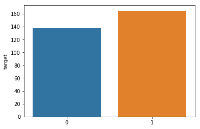

```python
sns.barplot(x= [0,1], y = df_tarefa_1['target'].groupby(df_tarefa_1['target']).count())
```

#### Separar, aleatoriamente e de forma equilibrada, o dataset, utilizando 70% como conjunto de treinamento

```python
def split_data(data: 'DataFrame', target_name: str, train_size: float = .7):
    train_data = []
    test_data = []

    # ordenar pelo target para distribuir equilibradamente
    data = data.sort_values(by=[target_name])
    #print(data)

    for d in data.values:
        #print(d)
        c = np.random.choice(2, 1, p=[train_size, 1-train_size])
        #print(c)

        if c == 0:
            train_data.append(d)
        else:
            test_data.append(d)

    print(f'tamanho dataset original: {len(data)} ')
    print(f'tamanho dataset train: {len(train_data)} - {len(train_data)/len(data)*100:.2f}%')
    print(f'tamanho dataset test: {len(test_data)} - {len(test_data)/len(data)*100:.2f}%')

    return pd.DataFrame(train_data, columns=data.columns), pd.DataFrame(test_data, columns=data.columns)
```

```python
train_1, test_1 = split_data(df_tarefa_1, 'target')
```

```
tamanho dataset original: 303
tamanho dataset train: 214 - 70.63%
tamanho dataset test: 89 - 29.37%
```

### Proporção do treino

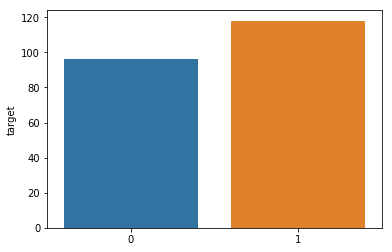

```python
sns.barplot(x= [0,1], y = train_1['target'].groupby(train_1['target']).count())
```

### Proporção do teste

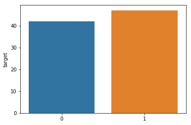

```python
sns.barplot(x= [0,1], y = test_1['target'].groupby(test_1['target']).count())
```

#### Implementar a função “predict_KNN(pontos,ponto)”, que recebe o conjunto de treinamento e o ponto cuja classe será predita e retornada.

```python
class myknn:
    def __init__(self, k):
        self.k = k
    def fit(self, data: 'DataFrame', target_name: str):

        self.data_original = data.copy()

        self.target = target_name

        self.data = self.data_original.drop(columns=[self.target])

        if (data[target_name].dtypes==object):
            self.mode = 'classifier'
        else:
            self.mode = 'regressor'

        print(f'mode {self.mode}')



    def predict_knn(self, ponto):
        # guarda ponto original - pandas Series
        self.ponto_original = ponto
        # tira o target do ponto para facilitar os cálculos
        self.ponto = ponto.drop(self.target)

        aux_data = self.data.copy()

        print(f"ponto original:\n {self.ponto_original}")

        # lista de diferenças
        dif = []
        # distância euclidiana de cada ponto - pandas DataFrame row
        for index, row in aux_data.iterrows():
            dif.append(np.sqrt(sum((row - self.ponto)**2)))

        # adicionar a coluna de diferenças
        aux_data['dif'] = dif
        # adicionar a coluna target
        aux_data[self.target] = self.data_original[self.target].copy()

        # sortear o dataset pelas diferenças
        sorted_ar = aux_data.sort_values(by=['dif'])

        # se for um classifier, prever pela moda do target dos k pontos mais próximos
        # se for um regressor, prever pela média do target dos k pontos mais próximos
        pred = -1
        if self.mode == 'classifier':
            pred = sorted_ar[self.target].iloc[0:self.k].mode().iloc[0]
        elif self.mode == 'regressor':
            pred = sorted_ar[self.target].iloc[0:self.k].mean()
        else: raise TypeError()

        print(f'pred: {pred}')

        return pred
```

```python
knn = myknn(6)
knn.fit(train_1, 'target')
```

```
mode classifier
```

```python
ponto_teste_1_1 = test_1.iloc[20]
ponto_teste_1_2 = test_1.iloc[60]
```

```python
pred_1_1 = knn.predict_knn(ponto_teste_1_1)
```

```
ponto original:
 age         61
chol       207
thalach    138
target       0
Name: 20, dtype: object
pred: 0
```

```python
pred_1_2 = knn.predict_knn(ponto_teste_1_2)
```

```
ponto original:
 age         65
chol       417
thalach    157
target       1
Name: 60, dtype: object
pred: 0
```

#### Scatter plot 3D mostrando os pontos de treinamento, os pontos que estão sendo preditos (acima deles, deve haver uma annotation com a classe em que foram classificados) e um código de cores intuitivo.

```python
import plotly.express as px
#'age', 'chol', 'thalach'
#df_tarefa_1.target = df_tarefa_1.target.apply(lambda x: str(x))
#df_tarefa_1.target = df_tarefa_1.target.astype(str)
fig = px.scatter_3d(df_tarefa_1, x='age', y='chol', z='thalach',color='target',
                    color_discrete_sequence=["coral", "darkturquoise"])
fig.update_layout(scene=dict(
    annotations=[dict( showarrow=True,
                      x=ponto_teste_1_1['age'],
                      y=ponto_teste_1_1['chol'],
                      z=ponto_teste_1_1['thalach'],
                      text=f"{ponto_teste_1_1['age'],ponto_teste_1_1['chol'],ponto_teste_1_1['thalach'],}({pred_1_1})",
                      font=dict(color="purple", size=14 ),
                      xanchor="center",
                      xshift=0,
                      opacity=1.0),
                 dict( showarrow=True,
                      x=ponto_teste_1_2['age'],
                      y=ponto_teste_1_2['chol'],
                      z=ponto_teste_1_2['thalach'],
                      text=f"{ponto_teste_1_2['age'],ponto_teste_1_2['chol'],ponto_teste_1_2['thalach'],}({pred_1_2})",

                      font=dict(color="purple", size=14 ),
                      xanchor="center",
                      xshift=0,
                      opacity=1.0)]))
fig.show()
```

[interactive chart not shown]

#### Comparar o resultado com o obtido através do sklearn.neighbors.KNeighborsClassifier

```python
ponto_teste_1_1
```

```
age         61
chol       207
thalach    138
target       0
Name: 20, dtype: object
```

```python
ponto_teste_1_2
```

```
age         65
chol       417
thalach    157
target       1
Name: 60, dtype: object
```

```python
from sklearn.neighbors import KNeighborsClassifier
sk_knn_1 = KNeighborsClassifier(n_neighbors=6)
['age', 'chol', 'thalach']
sk_knn_1.fit(train_1[['age', 'chol', 'thalach']], train_1['target'])
sk_pred_1_1 = sk_knn_1.predict([ponto_teste_1_1.drop(labels=['target'])])
sk_pred_1_2 = sk_knn_1.predict([ponto_teste_1_2.drop(labels=['target'])])
print(f'meu pred: {pred_1_1} - sklearn pred: {sk_pred_1_1}')
print(f'meu pred: {pred_1_2} - sklearn pred: {sk_pred_1_2}')
```

```
meu pred: 0 - sklearn pred: ['0']
meu pred: 0 - sklearn pred: ['0']
```

### Tarefa 2

#### Implementar a função “predict_KNN(pontos,ponto)”, que recebe o conjunto de treinamento e o ponto cuja classe será predita, porém, aqui, trata-se de uma regressão. Considerar as features como sendo apenas age e chol, tendo thalach como o alvo da regressão. Esta tarefa deve ser realizada nos dois datasets fornecidos.

```python
df_tarefa_2 = df[['age', 'chol', 'thalach']]
df_tarefa_2.head()
```

|  | age | chol | thalach |
| --- | --- | --- | --- |
| 0 | 63 | 233 | 150 |
| 1 | 37 | 250 | 187 |
| 2 | 41 | 204 | 172 |
| 3 | 56 | 236 | 178 |
| 4 | 57 | 354 | 163 |

```python
train_2, test_2 = split_data(df_tarefa_2, 'thalach')
```

```
tamanho dataset original: 303
tamanho dataset train: 218 - 71.95%
tamanho dataset test: 85 - 28.05%
```

### Distribuição treino-teste tarefa 2

#### Por se tratar de uma regressão para prever o "thalach", estamos interessados na distribuição dessa variável.

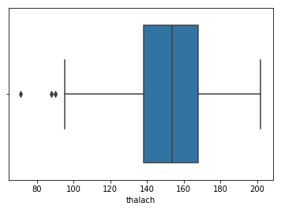

```python
sns.boxplot(train_2['thalach'])
```

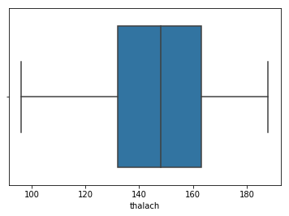

```python
sns.boxplot(test_2['thalach'])
```

```python
knn = myknn(6)
knn.fit(train_2, 'thalach')
```

```
mode regressor
```

```python
ponto_teste_2_1 = test_2.iloc[0]
ponto_teste_2_2 = test_2.iloc[10]
print(ponto_teste_2_1)
print(ponto_teste_2_2)
```

```
age         60
chol       178
thalach     96
Name: 0, dtype: int64
age         57
chol       289
thalach    124
Name: 10, dtype: int64
```

```python
pred_2_1 = knn.predict_knn(ponto_teste_2_1)
pred_2_2 = knn.predict_knn(ponto_teste_2_2)
```

```
ponto original:
 age         60
chol       178
thalach     96
Name: 0, dtype: int64
pred: 143.5
ponto original:
 age         57
chol       289
thalach    124
Name: 10, dtype: int64
pred: 147.0
```

```python
import plotly.express as px
#'age', 'chol', 'thalach'
#df_tarefa_1.target = df_tarefa_1.target.apply(lambda x: str(x))
#df_tarefa_1.target = df_tarefa_1.target.astype(str)
fig = px.scatter_3d(df_tarefa_2, x='age', y='chol', z='thalach')

fig.update_layout(scene=dict(
    annotations=[dict( showarrow=True,
                      x=ponto_teste_2_1['age'],
                      y=ponto_teste_2_1['chol'],
                      z=ponto_teste_2_1['thalach'],

                      text=f"{ponto_teste_2_1['age'],ponto_teste_2_1['chol'],ponto_teste_2_1['thalach'],}({pred_2_1:.2f})",
                      font=dict(color="lightsalmon", size=14 ),
                      xanchor="center",
                      xshift=0,
                      opacity=1.0),

                 dict( showarrow=True,
                      x=ponto_teste_2_2['age'],
                      y=ponto_teste_2_2['chol'],
                      z=ponto_teste_2_2['thalach'],

                      text=f"{ponto_teste_2_2['age'],ponto_teste_2_2['chol'],ponto_teste_2_2['thalach'],}({pred_2_2:.2f})",
                      font=dict(color="lightsalmon", size=14 ),
                      xanchor="center",
                      xshift=0,
                      opacity=1.0),

                ]))
fig.show()
```

[interactive chart not shown]

#### Comparar o resultado com o obtido através do sklearn.neighbors.KNeighborsRegressor

```python
print(ponto_teste_2_1)
print(ponto_teste_2_2)
```

```
age         60
chol       178
thalach     96
Name: 0, dtype: int64
age         57
chol       289
thalach    124
Name: 10, dtype: int64
```

```python
from sklearn.neighbors import KNeighborsRegressor
sk_knn_2 = KNeighborsRegressor(n_neighbors=6)
['age', 'chol', 'thalach']
sk_knn_2.fit(train_2[['age', 'chol']], train_2['thalach'])
sk_pred_2_1 = sk_knn_2.predict([ponto_teste_2_1.drop(labels=['thalach'])])
sk_pred_2_2 = sk_knn_2.predict([ponto_teste_2_2.drop(labels=['thalach'])])
print(f'meu pred: {pred_2_1} - sklearn pred: {sk_pred_2_1}')
print(f'meu pred: {pred_2_2} - sklearn pred: {sk_pred_2_2}')
```

```
meu pred: 143.5 - sklearn pred: [143.5]
meu pred: 147.0 - sklearn pred: [147.]
```

#### Erro previsão

```python
print(ponto_teste_2_1['thalach'] - sk_pred_2_1)
print(ponto_teste_2_2['thalach'] - sk_pred_2_2)
```

```
[-47.5]
[-23.]
```

### Dataset Covid

```python
df_covid = pd.read_csv('data\meu_dataset.csv')
df_covid.head()
```

|  | county | cases | deaths |
| --- | --- | --- | --- |
| 0 | Abbeville | 84 | 0 |
| 1 | Acadia | 741 | 21 |
| 2 | Accomack | 116 | 0 |
| 3 | Ada | 4264 | 41 |
| 4 | Adair | 325 | 8 |

```python
cov_train, cov_test = split_data(df_covid,'deaths',0.7)
```

```
tamanho dataset original: 1570
tamanho dataset train: 1076 - 68.54%
tamanho dataset test: 494 - 31.46%
```

### Nosso dataset do Covid possui uma distribuição extemamente concentrada

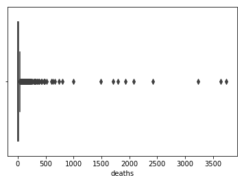

```python
sns.boxplot(cov_train.deaths)
```

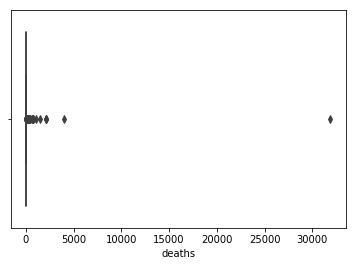

```python
sns.boxplot(cov_test.deaths)
```

```python
knn_cov = myknn(6)
knn_cov.fit(cov_train, 'deaths')
```

```
mode regressor
```

```python
cov_p_1 = cov_test.iloc[150]
cov_p_2 = cov_test.iloc[200]
print(f'ponto 1 :\n{cov_p_1}')
print(f'ponto 2 :\n{cov_p_2}')
```

```
ponto 1 :
county    St. Mary's
cases            419
deaths             0
Name: 150, dtype: object
ponto 2 :
county    Camas
cases        10
deaths        0
Name: 200, dtype: object
```

```python
pred_cov_1 = knn_cov.predict_knn(cov_p_1.drop(labels=['county']))
pred_cov_2 = knn_cov.predict_knn(cov_p_2.drop(labels=['county']))
```

```
ponto original:
 cases     419
deaths      0
Name: 150, dtype: object
pred: 0.0
ponto original:
 cases     10
deaths     0
Name: 200, dtype: object
pred: 0.0
```

```python
fig = px.scatter(df_covid, x="cases", y="deaths")
fig.add_annotation(
            x=cov_p_1.cases,
            y=cov_p_1.deaths,
            text=f"predito: {pred_cov_1}")
fig.add_annotation(
            x=cov_p_2.cases,
            y=cov_p_2.deaths,
            text=f"predito: {pred_cov_2}")
fig.update_annotations(dict(
            xref="x",
            yref="y",
            showarrow=True,
            arrowhead=7,
            ax=0,
            ay=-40
))
fig.show()
```

[interactive chart not shown]

```python
sk_knn_cov = KNeighborsRegressor(n_neighbors=6)
sk_knn_cov.fit(cov_train[['cases']], cov_train['deaths'])
sk_pred_cov_1 = sk_knn_cov.predict([[cov_p_1['cases']]])
sk_pred_cov_2 = sk_knn_cov.predict([[cov_p_2['cases']]])
print(f'meu pred: {pred_cov_1} - sklearn pred: {sk_pred_cov_1}')
print(f'meu pred: {pred_cov_2} - sklearn pred: {sk_pred_cov_2}')
```

```
meu pred: 0.0 - sklearn pred: [11.33333333]
meu pred: 0.0 - sklearn pred: [0.]
```